# Assignmet 3: Incarceration

## Intrroduction and Summary Information

Prisons and jails have become an increasingly controversial topic in the United States. Type **US prison system** into Google and the first thing that will pop up is **US prison system is legalized slavery**. I decided to use the variables **black_prison_adm_rate, black_male_prison_pop, black_female_prison_pop, total_prison_pop, total_prison_adm_rate** because all of them will help to analyze the biggest issue within the prison system, systemic racism. With the right charts and graphs, I believe these variables will allow me to inspect some of the underlying issues within the prison system.

With these variables, I will be able to dive into specific data points such as:

- Which state has the highest jail population in the most recent year?

CA

- Which county in California has the largest jail population in the most recent year?

Los Angeles County

- Which year was the Latinx prison population at its max?

2008

## Trends Over Time Chart

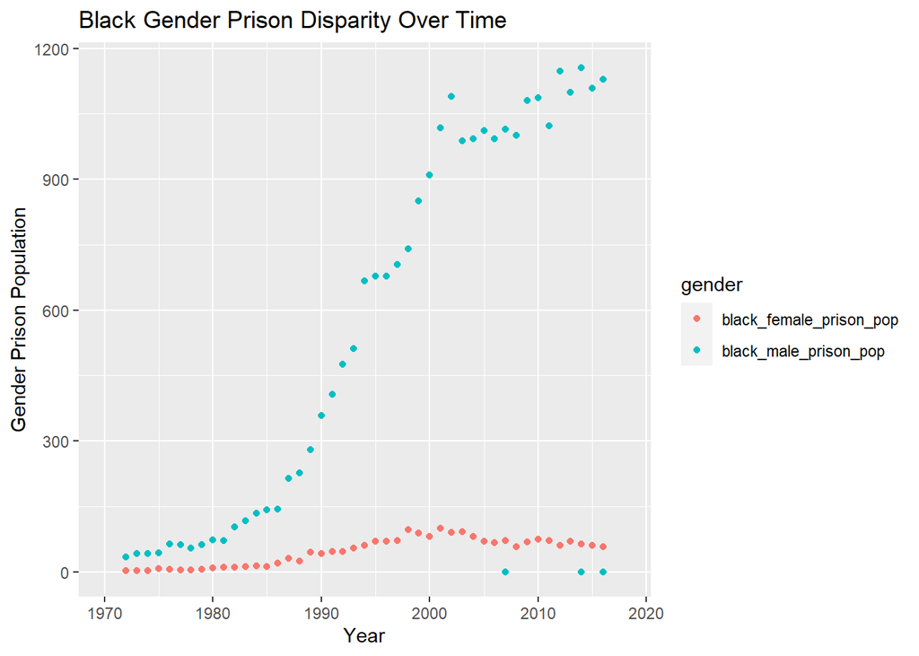

I decided to include this chart because I wanted to illustrate if there was a difference between the black male and black female prison population, and how this relationship changed over time. The main thing that this graph displayed was how much the black male prison population increased over time while the black female prison population remained pretty close to constant. I was surprised by this, as I thought both would have risen over time.

## Variable Comparison Chart

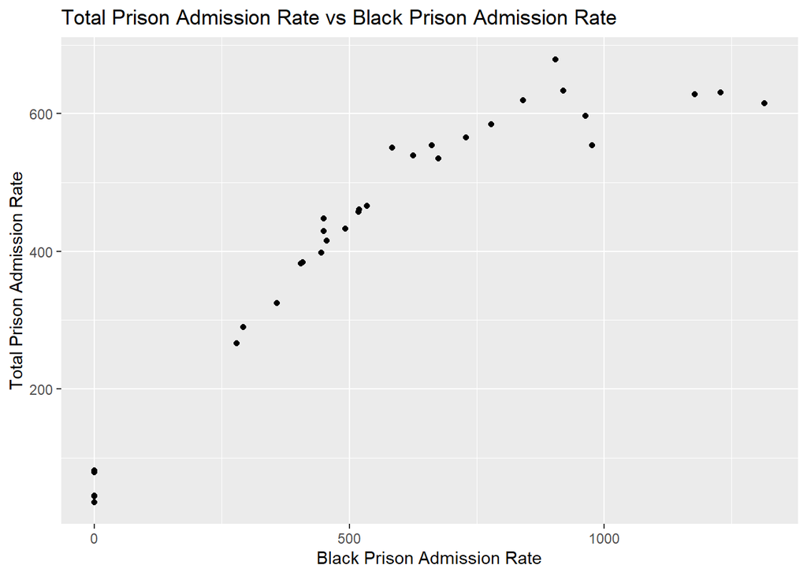

## Map

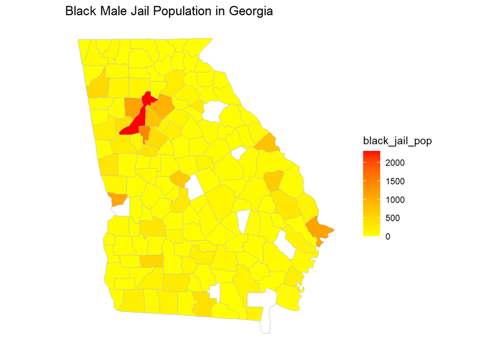

The reason I decided to create a map of the black male jail population in Georgia is because I wanted to see a heat map of a state with pockets of high urban populations with the outskirts being predominantly white. I assumed that the highest black male population in Georgia would be in and around Atlanta, and as the map illustrates this theory was correct.